# Decision Tree November 2025

Kode ringkas dan jawaban Tugas 5 (a)–(e)

2026-10-07

Simpan file di working directory R dengan nama aslinya, `Soal1_dataCar_data untuk peserta ujian.xlsx`, agar kode baca data di bawah langsung jalan.

Data soal November 2025 (Excel) · 3.2 MB

**Cara menjalankan:** letakkan Rmd dan Excel terlampir dalam folder yang sama, buka Rmd di RStudio, lalu klik **Knit**. Jika nama Excel berubah, sesuaikan nama pada `read_excel()`.

**Pembagian isi:** bagian 1 berisi kode minimum untuk membuat output dari Excel. Bagian 2 menjawab **(a)–(e) berdasarkan angka dan gambar pada PPT**. Hasil latihan dapat berbeda karena data dan pengaturan analisis asli tidak sepenuhnya sama.

**Target yang dianalisis adalah Claim/NoClaim.** Pengantar soal menyebut fraud, tetapi kolom `clm`, pohon, dan confusion matrix menunjukkan status klaim. Data ini tidak menyediakan label fraud, sehingga klaim tidak boleh langsung disamakan dengan kecurangan.

# 1. Kode minimum untuk membuat output

## 1.1. Library dan data

Instalasi cukup sekali di Console jika paket belum tersedia.

```r
install.packages(c("readxl", "rpart", "rpart.plot", "caret",
                   "pROC", "rmarkdown"))
```

```r
library(readxl)
library(rpart)
library(rpart.plot)
library(caret)
library(pROC)
```

```r
data <- read_excel("Soal1_dataCar_data untuk peserta ujian.xlsx")
data$clm <- factor(data$clm, levels = c(0, 1),
                    labels = c("NoClaim", "Claim"))

data <- data[, c("veh_value", "exposure", "veh_body", "veh_age",
                 "gender", "area", "agecat", "clm")]
data <- na.omit(data)
data[c("veh_body", "veh_age", "gender", "area", "agecat")] <-
  lapply(data[c("veh_body", "veh_age", "gender", "area", "agecat")], factor)

table(data$clm)
```

```
##
## NoClaim   Claim
##   63189    4617
```

```r
prop.table(table(data$clm))
```

```
##
##    NoClaim      Claim
## 0.93190868 0.06809132
```

`clm = 1` berarti Claim. `numclaims` dan `claimcst0` dikeluarkan dari prediktor karena mengandung informasi kejadian/biaya klaim yang sedang diprediksi (*data leakage*). `veh_age` dan `agecat` merupakan kode kelompok sehingga diperlakukan sebagai faktor.

Data Excel awal berisi **67.856 baris: 63.232 NoClaim dan 4.624 Claim**. Setelah 50 baris dengan `area` kosong dihapus, tersisa **67.806 baris: 63.189 NoClaim dan 4.617 Claim**. Jumlah ini berbeda dari PPT (**67.376 baris: 62.765 NoClaim dan 4.611 Claim**). Soal tidak menjelaskan seluruh tahap pembersihan sebelumnya, sehingga kode tidak memaksakan jumlah baris agar sama.

Terdapat pula kode `agecat = 60` yang perlu dikonfirmasi karena sebagian besar kode berada pada 1–6. Kode ini dipertahankan sebagai kategori tersendiri; tidak otomatis diganti menjadi 6 tanpa kamus data. Baris yang nilainya identik juga tidak otomatis dihapus karena tidak tersedia ID polis untuk memastikan bahwa baris tersebut duplikat pencatatan.

## 1.2. Split training dan testing

```r
set.seed(123)
id <- createDataPartition(data$clm, p = 0.7, list = FALSE)
train <- data[id, ]
test <- data[-id, ]
```

Training 70% digunakan untuk melatih model; testing 30% untuk evaluasi. `createDataPartition()` menjaga proporsi kelas. Seed dan proporsi ini adalah pilihan latihan, bukan klaim bahwa pengaturan asli soal telah diketahui.

## 1.3. Undersampling training

```r
set.seed(123)
train_balance <- downSample(train[, 1:7], train$clm, yname = "clm")

table(train$clm)
```

```
##
## NoClaim   Claim
##   44233    3232
```

```r
table(train_balance$clm)
```

```
##
## NoClaim   Claim
##    3232    3232
```

`downSample()` mengambil sebagian NoClaim secara acak sampai jumlahnya sama dengan Claim. Undersampling hanya dilakukan pada **training setelah split**. Testing tetap memakai proporsi kelas asal agar hasil evaluasi tidak terlalu optimistis.

## 1.4. Model dan gambar pohon

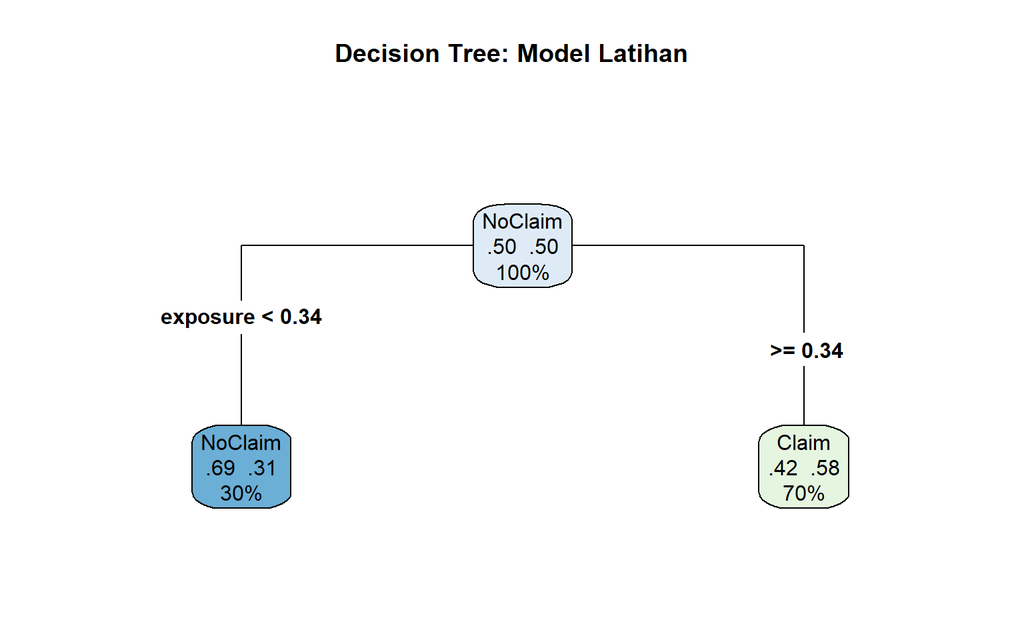

```r
model <- rpart(clm ~ ., data = train_balance, method = "class",
               control = rpart.control(cp = 0.01, maxdepth = 1))
rpart.plot(model, type = 4, extra = 104, fallen.leaves = TRUE,
           main = "Decision Tree: Model Latihan")
```

`method = "class"` untuk klasifikasi. `maxdepth = 1` membatasi pohon menjadi paling banyak satu split seperti bentuk pohon soal. Model tetap memilih prediktor dan batas split dari data latihan. `cp` mengendalikan syarat perbaikan untuk menambah split. Pengaturan ini dipilih agar latihan sederhana, bukan hasil pencarian model terbaik.

Cara membaca kotak node: **kelas prediksi**, lalu proporsi **NoClaim dan Claim**, lalu persentase data training seimbang yang masuk ke node. Proporsi setelah undersampling bukan probabilitas klaim yang terkalibrasi terhadap populasi asal.

## 1.5. Prediksi dan confusion matrix

```r
pred <- predict(model, test, type = "class")
cm <- confusionMatrix(pred, test$clm, positive = "Claim",
                       mode = "everything")
cm
```

```
## Confusion Matrix and Statistics
##
##           Reference
## Prediction NoClaim Claim
##    NoClaim    7663   244
##    Claim     11293  1141
##
##                Accuracy : 0.4328
##                  95% CI : (0.426, 0.4397)
##     No Information Rate : 0.9319
##     P-Value [Acc > NIR] : 1
##
##                   Kappa : 0.0486
##
##  Mcnemar's Test P-Value : <2e-16
##
##             Sensitivity : 0.82383
##             Specificity : 0.40425
##          Pos Pred Value : 0.09176
##          Neg Pred Value : 0.96914
##               Precision : 0.09176
##                  Recall : 0.82383
##                      F1 : 0.16513
##              Prevalence : 0.06809
##          Detection Rate : 0.05609
##    Detection Prevalence : 0.61128
##       Balanced Accuracy : 0.61404
##
##        'Positive' Class : Claim
##
```

Urutan yang perlu dihafal: **prediksi dulu, aktual kemudian**. Tetapkan `positive = "Claim"` agar sensitivity, precision, dan F1 menilai kasus klaim. Kode pada gambar soal tidak mencantumkan kelas positif; jika level pertama adalah NoClaim, metrik default akan mengacu pada NoClaim.

## 1.6. ROC dan AUC

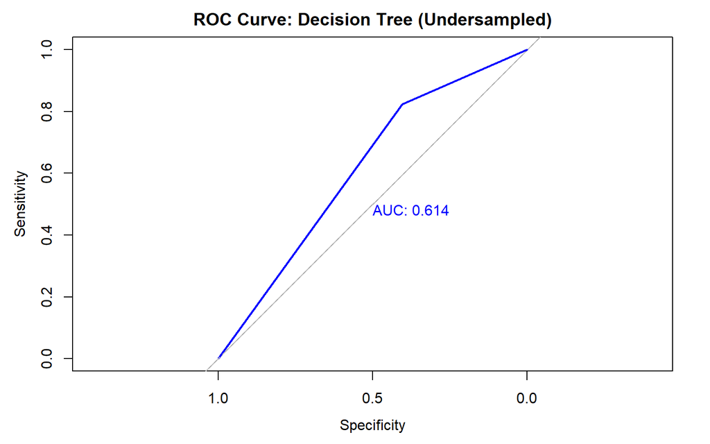

```r
prob <- predict(model, test, type = "prob")[, "Claim"]
roc_model <- roc(test$clm, prob,
                 levels = c("NoClaim", "Claim"), direction = "<")
plot(roc_model, col = "blue", print.auc = TRUE,
     main = "ROC Curve: Decision Tree (Undersampled)")
abline(a = 1, b = -1, lty = 2, col = "grey")
```

```r
auc(roc_model)
```

```
## Area under the curve: 0.614
```

ROC menggunakan **probabilitas Claim**, bukan label prediksi. `levels` menetapkan NoClaim sebagai kontrol dan Claim sebagai kasus. Angka AUC dari kode ini adalah milik model latihan.

# 2. Jawaban langsung berdasarkan soal

## (a) Hasil klasifikasi jika tidak dilakukan undersampling (3 poin)

Data pada PPT berisi **62.765 NoClaim (93,16%)** dan **4.611 Claim (6,84%)**. Tanpa penanganan ketidakseimbangan, decision tree cenderung mengutamakan kelas mayoritas NoClaim. Akibatnya, akurasi dapat terlihat tinggi, tetapi banyak pemegang polis yang benar-benar mengajukan klaim justru diprediksi NoClaim, sehingga recall Claim rendah.

Sebagai ilustrasi, model yang selalu memprediksi **NoClaim** akan memiliki akurasi **93,16%**, tetapi recall Claim **0%**. Ini menunjukkan mengapa akurasi saja tidak cukup. Model tanpa undersampling tidak pasti selalu memprediksi NoClaim, tetapi mempunyai kecenderungan tersebut ketika informasi pemisahan kelas lemah atau pohon dibatasi terlalu ketat.

## (b) Alternatif selain undersampling (2 poin)

| Alternatif | Penjelasan singkat |
| --- | --- |
| Random oversampling | Mengulang observasi Claim pada training sampai kelas lebih seimbang. Seluruh NoClaim tetap digunakan, tetapi pengulangan dapat meningkatkan risiko overfitting. |
| SMOTE / SMOTENC | Membentuk contoh sintetis kelas minoritas. Untuk data dengan prediktor kategori seperti ini, gunakan metode yang menangani kategori, misalnya SMOTENC. |
| Class weight / cost-sensitive learning | Memberi bobot atau penalti lebih besar jika Claim salah diprediksi sebagai NoClaim, sehingga kesalahan pada kelas minoritas lebih diperhatikan. |

Penyesuaian threshold juga dapat digunakan untuk meningkatkan recall Claim, dengan konsekuensi lebih banyak false positive. Pilih threshold pada data validasi, bukan dengan mengoptimalkannya pada testing.

## (c) Faktor penting dan aturan keputusan (3 poin)

Berdasarkan pohon pada PPT, faktor yang dipakai adalah **`exposure`**, yaitu lama paparan/periode pertanggungan yang diamati. Pohon hanya memiliki satu split dengan batas **0,35**.

| Aturan pada gambar | Prediksi | Proporsi NoClaim / Claim pada node | Bagian training seimbang |
| --- | --- | --- | --- |
| `exposure < 0.35` | NoClaim | 70% / 30% | 30% |
| `exposure >= 0.35` | Claim | 41% / 59% | 70% |

**Jawaban:** pemegang polis dengan exposure di bawah 0,35 diprediksi NoClaim, sedangkan exposure minimal 0,35 diprediksi Claim. Periode paparan yang lebih panjang memberi lebih banyak kesempatan terjadinya klaim selama periode pengamatan.

Angka 59% adalah proporsi Claim pada node **training yang sudah diseimbangkan**, bukan peluang klaim 59% pada seluruh pemegang polis. Exposure merupakan satu-satunya faktor yang dipakai pada pohon ini; hal tersebut tidak membuktikan bahwa seluruh variabel lain tidak relevan pada model atau data lain.

Untuk penggunaan sebelum kejadian, exposure harus merupakan informasi yang sudah tersedia saat prediksi. Hubungan ini juga tidak otomatis menunjukkan risiko per satuan waktu lebih tinggi, karena model memprediksi ada/tidaknya klaim selama periode pengamatan.

## (d) Performa model dan metrik evaluasi (5 poin)

Dengan **Claim sebagai kelas positif**, confusion matrix pada PPT adalah:

| Prediksi / Aktual | NoClaim | Claim |
| --- | --- | --- |
| NoClaim | TN = 7.800 | FN = 277 |
| Claim | FP = 11.029 | TP = 1.106 |

Hitung metrik langsung dari angka soal menggunakan library:

```r
mat_soal <- matrix(c(7800, 277, 11029, 1106), nrow = 2, byrow = TRUE,
                    dimnames = list(Prediksi = c("NoClaim", "Claim"),
                                    Aktual = c("NoClaim", "Claim")))
cm_soal <- confusionMatrix(as.table(mat_soal), positive = "Claim",
                            mode = "everything")
cm_soal
```

```
## Confusion Matrix and Statistics
##
##          Aktual
## Prediksi  NoClaim Claim
##   NoClaim    7800   277
##   Claim     11029  1106
##
##                Accuracy : 0.4406
##                  95% CI : (0.4338, 0.4475)
##     No Information Rate : 0.9316
##     P-Value [Acc > NIR] : 1
##
##                   Kappa : 0.0465
##
##  Mcnemar's Test P-Value : <2e-16
##
##             Sensitivity : 0.79971
##             Specificity : 0.41425
##          Pos Pred Value : 0.09114
##          Neg Pred Value : 0.96571
##               Precision : 0.09114
##                  Recall : 0.79971
##                      F1 : 0.16363
##              Prevalence : 0.06842
##          Detection Rate : 0.05472
##    Detection Prevalence : 0.60039
##       Balanced Accuracy : 0.60698
##
##        'Positive' Class : Claim
##
```

| Metrik | Nilai dari soal | Interpretasi |
| --- | --- | --- |
| Accuracy | 44,06% | Sebanyak 8.906 dari 20.212 prediksi benar. |
| Recall / Sensitivity Claim | 79,97% | Menangkap 1.106 dari 1.383 klaim aktual. |
| Specificity | 41,43% | Mengenali 7.800 dari 18.829 NoClaim aktual. |
| Precision Claim | 9,11% | Hanya 1.106 dari 12.135 prediksi Claim yang benar. |
| F1 Claim | 16,36% | Rendah karena precision rendah meskipun recall cukup tinggi. |
| Balanced accuracy | 60,70% | Rata-rata recall Claim dan specificity. |

**Penilaian:** model menangkap sekitar 80% klaim aktual, tetapi menghasilkan **11.029 false positive** dan masih melewatkan **277 klaim**. Sekitar 91 dari 100 prediksi Claim ternyata NoClaim. Dengan demikian, model belum baik untuk keputusan yang membutuhkan prediksi Claim yang presisi, walaupun dapat membantu penyaringan awal jika tindak lanjutnya murah.

**Metrik yang dipilih:** utamakan **recall Claim** jika klaim terlewat menjadi perhatian utama. Lengkapi dengan **precision dan F1** untuk menilai beban alarm palsu, serta **balanced accuracy** untuk menilai kedua kelas lebih setara. **ROC-AUC** mengukur kemampuan pemeringkatan pada berbagai threshold. Akurasi saja tidak cukup pada data tidak seimbang ini.

Akurasi 44,06% memang lebih rendah daripada prediksi semua NoClaim yang sekitar 93,16%. Namun, prediksi semua NoClaim melewatkan seluruh klaim. Pemilihan model perlu mempertimbangkan recall sekaligus biaya false positive dan false negative.

## (e) Kesimpulan ROC dan bentuk ROC model yang baik (2 poin)

Kurva ROC pada gambar berada di atas garis acak, tetapi masih cukup dekat dengan garis tersebut. Ini menunjukkan kemampuan membedakan Claim dan NoClaim **lebih baik daripada acak, tetapi masih terbatas**. Recall sekitar 80% diperoleh dengan false positive rate sekitar **58,57%**, sehingga banyak NoClaim ikut ditandai sebagai Claim.

Pada gambar, sumbu X adalah **specificity yang menurun dari kiri ke kanan**. Model yang baik mempunyai kurva mendekati **pojok kiri atas**, yaitu sensitivity dan specificity sama-sama mendekati 1, serta AUC mendekati 1. Pada plot dengan sumbu X berupa `1 - specificity`, tujuan tetap pojok kiri atas, tetapi nilai X yang diinginkan mendekati 0.

**Mengapa kurvanya hanya memiliki satu tekukan?** Pohon pada gambar mempunyai dua daun, sehingga hanya menghasilkan dua skor probabilitas Claim, sekitar 0,30 dan 0,59. Menggeser threshold hanya menghasilkan satu titik operasi di antara dua titik ekstrem ROC.

Khusus untuk pohon dua daun tersebut, dengan dua skor yang membedakan kedua kelompok, luas trapezoid ROC dapat dihitung dari rata-rata sensitivity dan specificity pada split itu:

```r
auc_soal <- mean(cm_soal$byClass[c("Sensitivity", "Specificity")])
auc_soal
```

```
## [1] 0.6069827
```

Hasilnya sekitar **0,607**, konsisten dengan kemampuan diskriminasi yang terbatas. Ini adalah **perhitungan dari struktur dua daun dan confusion matrix soal**, bukan angka AUC yang tercetak pada PPT. Hubungan AUC = balanced accuracy ini khusus untuk dua tingkat skor tersebut; jangan menerapkannya pada model dengan banyak skor probabilitas.

# 3. Pola kode yang perlu dihafal

| Kebutuhan | Fungsi utama |
| --- | --- |
| Baca data | `read_excel()` |
| Cek ketidakseimbangan | `table()` dan `prop.table()` |
| Split dengan proporsi kelas terjaga | `createDataPartition()` |
| Undersampling training | `downSample()` |
| Buat pohon klasifikasi | `rpart(..., method = "class")` |
| Gambar pohon | `rpart.plot()` |
| Prediksi kelas / probabilitas | `predict(..., type = "class")` / `type = "prob"` |
| Confusion matrix dan metrik | `confusionMatrix(..., positive = "Claim")` |
| ROC dan AUC | `roc()`, `plot()`, `auc()` |

**Sumber:** *Soal Decision Tree Nov 2025.pptx* dan *Soal1_dataCar_data untuk peserta ujian.xlsx*. Implementasi fungsi mengikuti dokumentasi [rpart](https://search.r-project.org/CRAN/refmans/rpart/html/rpart.html), [rpart.plot](https://search.r-project.org/CRAN/refmans/rpart.plot/html/prp.html), [downSample](https://search.r-project.org/CRAN/refmans/caret/html/downSample.html), [confusionMatrix](https://search.r-project.org/CRAN/refmans/caret/html/confusionMatrix.html), dan [pROC](https://search.r-project.org/CRAN/refmans/pROC/html/roc.html).

**Catatan verifikasi:** struktur data, jumlah kelas, dan perhitungan metrik soal sudah diperiksa. Eksekusi R/Knit belum diuji karena lingkungan penyusunan tidak menyediakan R.